# How Weighting Choices Change a Poll’s Result: Florida, 2016

One poll, five answers — 867 Florida voters, the weights that turned them into a result, and the winner that changes when you turn the dial

Democracy’s Data

Last updated September 13, 2026 at 10:53a EDT

Two pollsters holding the same interviews can publish different winners. That sounds like an accusation, and it is not one; it is a documented event, and the document is public. On 20 September 2016 *The New York Times* published a poll of Florida and then did something almost no pollster does: it gave the raw file away.

The Times and Siena College had interviewed 867 Florida voters and published a result, Clinton by one point. Alongside it, the Upshot, the Times’s data-journalism desk, handed the respondent-level data — one row per person interviewed, with every answer — to four outside pollsters and asked each to produce the estimate themselves. The four came back with four different answers, spread across five points, and they did not agree on who was ahead.

Nobody cheated and nobody made an arithmetic error. The 867 people were the same 867 people in every case. What differed was the **weighting**: counting some answers more than others, so that a sample which does not look like the electorate can be made to. How does the same file honestly yield different winners — and which decisions inside the weighting actually move the answer? The file that lets anyone check is still public, so this brief turns the dials and watches.

## The test

The data is the [2016 Times/Siena respondent-level poll file](https://github.com/TheUpshot/2016-upshot-siena-polls), released by the Times on GitHub: 4,879 respondents across six separate state polls, of which the September Florida poll is the 867 this brief reads. Florida’s certified November result, the answer sheet, comes from this book’s historical campaigns chapter.

Why this source, of all polls? Because it is very nearly the only one of its kind. A respondent-level poll file is normally the last thing a pollster releases, since it is the only thing that lets somebody else disagree with them in public. The Upshot released one on purpose, so that four rivals could contradict it in the same week. It carries the interviews *and* the two weights the Times applied, so the published answer can be checked rather than taken on trust — and every rival scheme can be rebuilt on the same people.

The mechanics of weighting are this section’s subject, and its weighting chapter walks through them on the largest survey that publishes its own. The short version to carry in: weighting is only the statistical step that makes a sample resemble a chosen picture of the electorate. The picture itself, how many college graduates and how many seniors, is benchmarked from outside. For a national poll that usually means the Census Bureau’s own surveys of who lives in the country;[^1] for a poll like this one, drawn from a state’s voter file — the state’s list of everyone registered to vote, with each person’s party registration and voting history — the file itself supplies much of the picture. This brief is about choosing the picture.

## The data

Everything below is built from `upshot-siena-polls.csv`, the poll file the New York Times and Siena College published on GitHub, downloadable by anyone: no key, no account, no guestbook. This is a newspaper’s file on a code-hosting site, not an archive; no statute obliges anyone to keep it there, and the version you download tomorrow is whatever the repository holds tomorrow. The small tables in this brief’s folder are kept for exactly that reason.

This brief keeps the 867 September Florida respondents, in three tables. `fl_respondents.csv` holds one row per person: `vote`; the Times’ two weights, `rvweight` and `lvweight` — a **registered-voter weight**, which makes the sample resemble everyone registered to vote in Florida, and a **likely-voter weight**, which makes it resemble the smaller group the Times expected to actually turn out; and seven columns describing who the person is — `educ4`, `race4`, `race_said`, `party3`, `age4`, `turnout3`, `region5`. Two of those deserve a flag. `race_said` is the race the respondent gave the interviewer; `race4` is the race Florida’s voter file records for the same person, and the two will matter separately below. `party3` and `turnout3` also come from the voter file: registration and vote history are records, not answers.

`schemes.csv` holds one row per weighting scheme — a `margin` and a `leader` for each way of treating the same people. And `targets.csv` holds what each scheme assumes the electorate looks like, variable by variable. Its Times columns are not copied from anywhere: they are recovered from the published weights, by a trick worth knowing because it applies to any survey that ships them. A weighted tabulation *is* a target. Weight the sample by the Times’ likely-voter weight and tabulate education, and what comes back is the education profile the Times assumed Florida’s likely voters had, because the weights were built to hit it.

Of the 867 respondents, 720 named one of the two major candidates; the other 147 named somebody else, refused, or said they would not vote. Every margin below is computed over the 720.

> **Before you read on, commit to a view.** The published poll said **Clinton +1**. **What was Clinton’s margin among the respondents before anybody weighted anything?** Not the published number — the raw count of who said what. Write it down; the gap between your guess and the answer is the brief.

## What it says about democracy

### The ladder

Three numbers, from the same 720 people.

| Weighted how | What it assumes | Margin | Leader |
| --- | --- | --- | --- |
| As collected | that the people who answered are the electorate | +9.2 | Clinton |
| Registered voters (Times) | that the electorate looks like Florida’s registered voters | +4.0 | Clinton |
| Likely voters (Times, published) | that it looks like the Times’ model of who turns out | +0.6 | Clinton |

**As collected, Clinton led by 9.2 points.** Published, she led by 0.6. The same people, 8.5 points apart. If you guessed two or three points above the published figure, you were short by a factor of three: the gap is more than eight. Weighting is not a rounding step applied to a result that already exists — it is most of how the result came to exist at all.

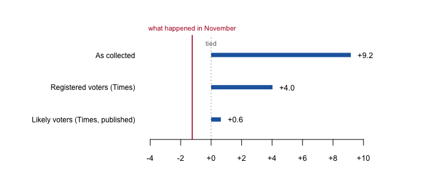

**Figure 1. The same 720 respondents under three weights**, drawn as bars from zero because the question is distance from a tie. The red rule is Florida’s actual two-party margin, -1.2.

Here is what a weight is, on one person. Of the 720 respondents who named a candidate, 393 said Clinton and 327 said Trump. 393 minus 327, divided by 720, is Clinton +9.2: that is the raw count, and it treats every answer as one answer. A weight is the number of answers the Times decided a person’s one answer should stand for. The 867 people who picked up the phone were more Democratic-registered, younger and less reliable past voters than the electorate the Times expected in November, so a respondent from a group the sample holds too many of counts for less than one, and a respondent from a group it holds too few of counts for more. The most heavily weighted respondent over 65 is a White registered Republican with a high turnout history from the Central region: the Times’ likely-voter weight for that person is 1.63, so the answer counts 1.63 times. The most lightly weighted registered Democrat sits at the other end of those dials — aged 18-34, Hispanic in the voter file, with a low turnout history — and carries a weight of 0.06, so that answer counts for roughly one part in 16 of one.

Now redo the subtraction with the weights. Under the likely-voter weight, Clinton’s 393 answers add up to 305.2 and Trump’s 327 add up to 301.3: 305.2 minus 301.3, divided by 606.6, is Clinton +0.6. Nobody’s answer changed. What changed is how many answers each one was worth.

### What the four pollsters were asked to do

The Upshot’s exercise was not a test of arithmetic. Each pollster received the same respondents and made their own decisions about two separate things.

First, **which people count as the electorate**. Every pollster applies some rule — a **likely-voter screen** — about who will actually turn out: a stated intention, a record of having voted before, a modeled score. The rules disagree. Second, **what the electorate is assumed to look like**: how many college graduates, how many registered Democrats, how many over 65. Then each scaled the respondents until the sample matched their picture.

Their published answers, as the article reported them:

| Pollster | Result |
| --- | --- |
| Omero, Green and Rosenblatt | Clinton +4 |
| Charles Franklin | Clinton +3 |
| The Times and Siena, as published | Clinton +1 |
| Patrick Ruffini | Clinton +1 |
| Gelman, Rothschild and Corbett-Davies | Trump +1 |

These five figures are quoted from the article, not computed here. The pollsters described their methods in prose rather than publishing code, and two of them used targets that are not in the released file. Nothing in this brief claims to have reproduced them.

That table is the reason this brief exists, and the one thing in it this brief cannot rebuild. What can be rebuilt is the mechanism the five answers came out of, on the file they all worked from.

### The electorate the Times assumed, recovered from its own weights

Read the Times’ recovered targets against the standard story about 2016 and one of them runs the wrong way.

| Variable | Level | As collected | Registered | Likely voters |
| --- | --- | --- | --- | --- |
| Education | Bachelor’s | 24.0 | 24.1 | 24.6 |
| Education | HS or less | 19.7 | 19.3 | 17.3 |
| Education | Postgraduate | 19.6 | 19.2 | 20.6 |
| Education | Refused | 1.4 | 1.3 | 1.3 |
| Education | Some college | 35.3 | 36.1 | 36.2 |
| Party registration | Democratic | 41.0 | 38.1 | 38.3 |
| Party registration | Other | 27.1 | 25.8 | 22.2 |
| Party registration | Republican | 31.9 | 36.1 | 39.5 |

The standard account of 2016 is that state polls held too many college graduates,[^2] so weighting should have pushed that share down. **It pushed it up.** 43.6% of the respondents held at least a bachelor’s degree, and the electorate the Times weighted to was 45.2% — 1.6 points *more* educated, not less. The reason is not an error. Likely voters really are better educated than registered voters, and the target was a likely-voter electorate, so the correction for one thing moved the other the wrong way.

### Turn the dial yourself

Here is the whole exercise, on the 867 respondents. Two sets of controls, because a pollster makes two separate decisions and they do not have the same consequences. **Which variables** get corrected at all, on the left. **What the electorate is assumed to look like** on each of them, on the right. The margin recomputes as you change either.

The numbers on the right are shares of that assumed electorate, not shares of the 867 people who answered. The levels of a variable therefore always add to 100%, and raising one lowers the others. Each slider is marked where the Times’ own target sat. The readout under the bar also reports an **effective sample size**: how many unweighted answers the weighted ones are worth. A respondent counted at a tenth is contributing almost nothing, so a sample whose weights vary widely is telling you less than its headcount suggests.[^3]

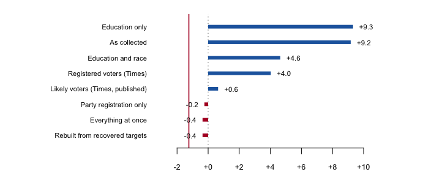

**Figure 2. In the browser, two sets of controls: which variables are corrected, and what the electorate is assumed to look like on each.** In print, eight fixed schemes instead, every one of them reachable with those controls.

### Which dial actually matters

Turn only the education slider and very little happens. Turn on party registration and the winner changes.

| Corrected for | Margin | Leader |
| --- | --- | --- |
| As collected | +9.2 | Clinton |
| Education only | +9.3 | Clinton |
| Party registration only | -0.2 | Trump |
| Education and race | +4.6 | Clinton |
| Everything at once | -0.4 | Trump |

**Correcting the education skew moves the margin by less than a fifth of a point.** Correcting the party mix moves it by more than nine, and across zero. The two corrections are the same operation on the same people. Only the choice of column is different.

Here is that operation for one dial at a time, because with one variable it is arithmetic anyone can check. 19.7% of the respondents have a high-school education or less, and the electorate the Times assumed has 17.3%, so every such respondent is given the weight 17.3 ÷ 19.7 = 0.88. Postgraduates are 19.6% of the sample and 20.6% of the target, so each of them counts 1.05. No education weight strays more than 0.12 from one, because the sample’s education mix was already close to the target, and the margin barely moves: that is the *Education only* row. Party registration is a different dial. Registered Democrats are 41.0% of the sample against 38.3% of the target, so each counts 0.94; registered Republicans are 31.9% against 39.5%, so each counts 1.24. And 86.3% of the registered Democrats named Clinton while 9.5% of the registered Republicans did, so shrinking the first group and enlarging the second moves the answer a long way: to the *Party registration only* row, and across zero.

That is the answer to the question the controls are really asking. The target you set matters, and it matters less than which variable you decided was worth setting a target for. A pollster who never thought about party registration never sees the number that flips the state, and nothing in the output announces the absence.

### Two files disagree about who these people are

One more thing sits inside the file, and it is the reason race is a harder dial than it looks. Every respondent has a race twice: the race they gave the interviewer, and the race the voter file records. **They disagree about 203 of the people who answered the question**, which is 24.7% of them.

Neither column is the truth. A pollster weighting to census categories uses the first, a pollster weighting to registration data uses the second, and the two are choosing between different people before either one sets a target. The BISG chapter grades a method that guesses race from a name and a neighbourhood against a state’s own record; this is the same problem arriving one step earlier, in a poll.

Put the pieces together and the finding is this. **A published poll is an estimate plus a set of judgments, and honest judgments disagree.** Both the Times’ answer and its opposite are reachable from the same interviews by decisions that are defensible one at a time. Reading polls well does not mean finding the pollster who cheated — nobody here cheated. It means knowing which dial moved, and noticing that the printed margin of error, how far off sampling luck alone could put the result, says nothing about any of the dials.

## What this brief cannot tell you

**It cannot reproduce the four pollsters’ answers.** Their methods were described in prose, not published as code. Two of the four used targets that are not in the released file, including a modeled estimate of the 2016 electorate. The five figures in the table above are quoted from the article.

**It cannot tell you which weighting was right.** Florida went -1.2, so the published poll missed by 1.9 points on the two-party margin and named the wrong winner. That does not make any of the rival schemes correct. One election is one draw, a scheme can be right for the wrong reason, and a poll taken in September is not a forecast of November.

**It cannot separate weighting error from everything else.** A poll can miss because the weights were wrong. It can miss because the people who answered differ from the people who did not, in ways no column captures. It can miss because voters changed their minds in the seven weeks that followed. Nothing here distinguishes those.

**The dials are coarser than a pollster’s.** Six variables, collapsed to a few levels each, on one state in one month of one year. A real weighting scheme runs on more variables and finer categories, and the sliders cannot express a likely-voter screen, which is a rule about *who counts* rather than about what they look like.

**And 867 people is a small number.** Before any of this, a sample that size carries a margin of error of roughly three points on a two-party split. Several of the gaps in Figure 2 are smaller than that.

## What you should have learned

- The published result was Clinton +0.6 and the respondents as collected were Clinton +9.2: weighting accounts for 8.5 points of margin on 720 people who never changed their answers.
- The choice of which variables to correct spans 9.7 points across the schemes in Figure 2 and crosses zero, so the same interviews can honestly produce either winner.
- Which variable you correct matters more than the target you set on it: education moved this poll by under a fifth of a point, party registration by more than nine.
- A survey that ships its weights has told you its assumed electorate, whether it meant to or not — a weighted tabulation is a target, and reading the weights backwards recovers it.
- A margin of error describes sampling only. Here the weighting did more work than the sampling did, and none of it is visible in a published topline.

## Extensions

- `schemes.csv` gives each weighting scheme a `margin` and a `leader`. Decide which scheme you would have run, before you look at which one was right.
- `targets.csv` shows what each scheme assumed the electorate looks like, column by column. Find the variable the schemes disagree about most. Is that an empirical question or a judgment call?
- `fl_respondents.csv` carries both `rvweight` and `lvweight` for every person. Sort by the ratio. Which kinds of respondent get pulled hardest when a pollster decides who is likely to vote?
- Compare `race_said` with `race4` in `fl_respondents.csv`, group by group. Which groups do the survey answer and the voter file disagree about most?
- *Stretch:* the released file holds five other state-waves. Run the ladder — raw, registered, likely — on another state, and see whether weighting always moves the margin the same direction it did here.
- *Stretch:* find a 2024 poll whose write-up names its weighting variables. List the dials it turned, the dials this file shows can matter, and which of them the write-up never mentions.

## Sources

**Data**

- **Poll data.** New York Times Upshot / Siena College, 2016 voter-file polls. `upshot-siena-polls.csv`, 4,879 respondents, 34 columns. https://github.com/TheUpshot/2016-upshot-siena-polls
- **The article.** Nate Cohn, “We Gave Four Good Pollsters the Same Raw Data. They Had Four Different Results,” *The Upshot*, 20 September 2016. The five quoted results come from it. The Times’s own address is www.nytimes.com/interactive/2016/09/20/upshot/the-error-the-polling-world-rarely-talks-about.html; an archived copy is at http://web.archive.org/web/20161002005137/http://www.nytimes.com/interactive/2016/09/20/upshot/the-error-the-polling-world-rarely-talks-about.html.
- **Florida’s actual 2016 result**, read from this book’s historical campaigns chapter rather than retyped, so the two cannot disagree.
- **The tables here.** The 867 September Florida respondents, cut from that file, with the Times’ targets recovered from its own published weights. Every number above is computed from them at the moment this document was rendered.

**Also cited**

- American Association for Public Opinion Research (2017). *An Evaluation of the 2016 Election Polls in the United States.* https://aapor.org/wp-content/uploads/2022/11/AAPOR-2016-Election-Polling-Report.pdf
- U.S. Census Bureau. *About the Current Population Survey.* https://www.census.gov/programs-surveys/cps/about.html
- Kish, Leslie (1965). *Survey Sampling.* New York: John Wiley & Sons.

**The data itself**

Every figure above is drawn from these tables. They are plain CSV, they open in a spreadsheet, and they are yours to take further.

`fl_respondents.csv`, `schemes.csv`, `targets.csv`

Two more files here are not data about the subject at all – they are how this chapter checked its own work: `facts.csv`, the individual numbers the text above quotes, and `checks.csv`, the arithmetic verified before anything was drawn.

**Checks**

| Check | Passed |
| --- | --- |
| the wave is the 867 the article is about | yes |
| both of the Times’ own weights are present on every row | yes |
| educ4 has no missing values to weight around | yes |
| race4 has no missing values to weight around | yes |
| party3 has no missing values to weight around | yes |
| age4 has no missing values to weight around | yes |
| turnout3 has no missing values to weight around | yes |
| region5 has no missing values to weight around | yes |
| the published Clinton +1 reproduces from the released weights | yes |
| weighting moves the margin by more than five points | yes |
| the education profile is not left where it was found | yes |
| the rebuilt weight lands within two points of the published margin | yes |
| the sibling chapter’s state returns are where this expects them | yes |
| exactly one Florida 2016 row | yes |
| the poll and the result disagree about who won Florida | yes |
| the committed respondent file is the whole wave, not a sample | yes |
| it carries nothing that could identify anybody | yes |

Rebuild this data yourself, with an AI assistant

```
I want to rebuild a public dataset from its original source, without any
starting files. Please do the following and show your work.

THE SOURCE. The New York Times' Upshot, respondent-level data from the
2016 New York Times/Siena College polls, released on GitHub in the
repository TheUpshot/2016-upshot-siena-polls. One CSV, about 2.3 MB,
downloaded raw from
https://raw.githubusercontent.com/TheUpshot/2016-upshot-siena-polls/master/upshot-siena-polls.csv
No account or key is needed. Each row is one person interviewed —
4,879 in all, across six state polls. The columns hold each person's
answers plus two weights the Times computed: rvweight, for registered
voters, and lvweight, for likely voters.

WHAT TO BUILD.
1. Keep only the September Florida poll. Among its respondents who
   named one of the two major candidates, compute Clinton's two-party
   margin over Trump three ways: with no weights at all, under
   rvweight, and under lvweight. The last is the figure the Times
   published as "Clinton +1".
2. A count of the Florida respondents who named one of the two major
   candidates, and of those who named somebody else, refused, or said
   they would not vote.

CHECK YOUR WORK. The copy this book used was downloaded in August 2026.
If your rebuild matches it, you should find:
- 4,879 rows in the file, 867 of them in the September Florida poll
- 720 of the 867 named Clinton or Trump; 147 did not
- the margin is Clinton +9.17 with no weights, +4.03 under rvweight,
  and +0.64 under lvweight — which rounds to the published +1
This is a finished release about one election and should never grow;
if your numbers differ, you are holding a changed copy of the file,
not making an arithmetic error.
```

[^1]: The usual benchmark is the Bureau’s Current Population Survey, a monthly survey of about 60,000 households that is the source of the official unemployment rate: https://www.census.gov/programs-surveys/cps/about.html.
[^2]: The polling profession’s own post-mortem found that many state polls in 2016 had not adjusted for education, and that college graduates — likelier to answer a poll, and likelier to back Clinton — were over-represented as a result: American Association for Public Opinion Research, *An Evaluation of the 2016 Election Polls in the United States* (2017), https://aapor.org/wp-content/uploads/2022/11/AAPOR-2016-Election-Polling-Report.pdf.
[^3]: The formula is Leslie Kish’s: *Survey Sampling* (New York: John Wiley & Sons, 1965).